# Client Report - [Car Selling Price]

- Show All Code
- Hide All Code

Check if I made a profit when I sold my car according to the market trend.

Author

Erin Hu

### CarSellingPrice

```r
library(readxl)
library(car)
library(tidyverse)
library(DT)
library(pander)
library(ggplot2)
carprice <- read_excel("~/Desktop/carprice.xlsx")
```

Here is my report for my old car (BMWX3), which I bought last year and sold it this summer. The price I bought was 9k, and the mileage at that time was 155000 miles, and the price I sold is 6.5k, and the mileage was 161250 miles.

## Graphical Summaries

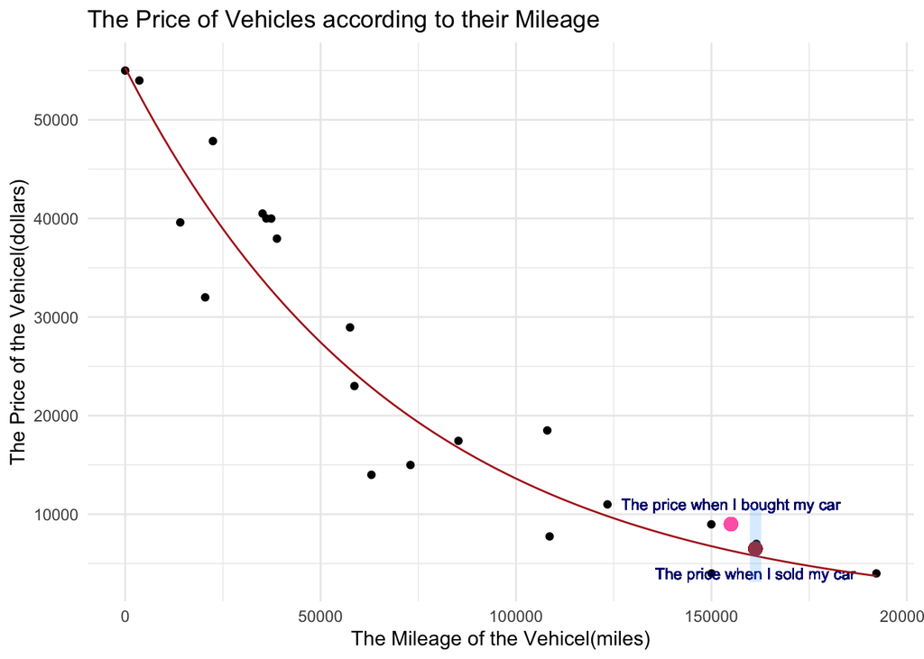

```r
ggplot(carprice, aes(x=Mileage, y =Price)) +
  geom_point() +
  geom_point(x = 155000, y = 9000, size = 3, color = "hotpink") +
  geom_text(x = 155000, y = 11000 , label = "The price when I bought my car", color = "navy", size = 3) +
  geom_point(x = 161250, y = 6500, size = 3, color = "firebrick") +
  geom_text(x = 161250, y = 4000 , label = "The price when I sold my car", color = "navy", size = 3) +
  labs(x="The Mileage of the Vehicel(miles)", y="The Price of the Vehicel(dollars)", title = "The Price of Vehicles according to their Mileage") +
  stat_function(fun=function(x) exp(10.92 - 0.00001401*x), add=TRUE, col="firebrick") +
  geom_segment(x=161250, xend=161250, y=3135.847, yend=10637.18,
               color="skyblue", alpha=0.01, lwd=3) +

    theme_minimal()
```

## Hypothesis

$$\underset{\text{Log Car Price}}{\log(Y_i)} = \overbrace{\beta_0}^{\text{Y-int}} + \overbrace{\beta_1}^{\text{Slope}} \underset{\text{Mileage}}{X_i} + \epsilon_i \quad \text{Where } \epsilon_i \sim N(0, \sigma^2)$$

**Hypothesis Test:**

$$H_0: \beta_1 = 0 \\
H_a: \beta_1 \neq 0$$

## Analysis

This the graph of all the data that I collect. The blue line is the regression line of the trend, but of course, the price in the real world is not gonna be a stright line.

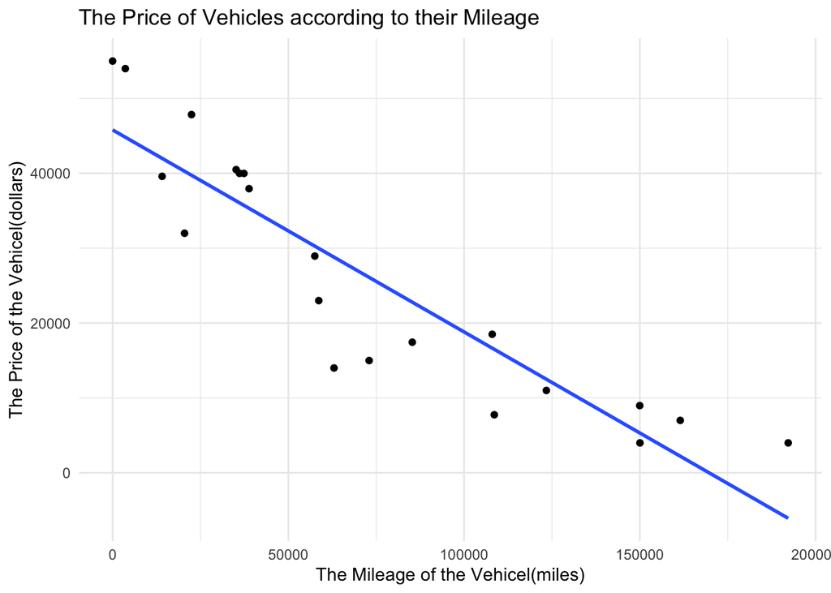

```r
ggplot(carprice, aes(x=Mileage, y =Price)) +
  geom_point() +
  geom_smooth(method ="lm", formula = y~x, se=FALSE) +
  labs(x="The Mileage of the Vehicel(miles)", y="The Price of the Vehicel(dollars)", title = "The Price of Vehicles according to their Mileage") +

    theme_minimal()
```

So I tried to find what is my λ by using boxCox function.

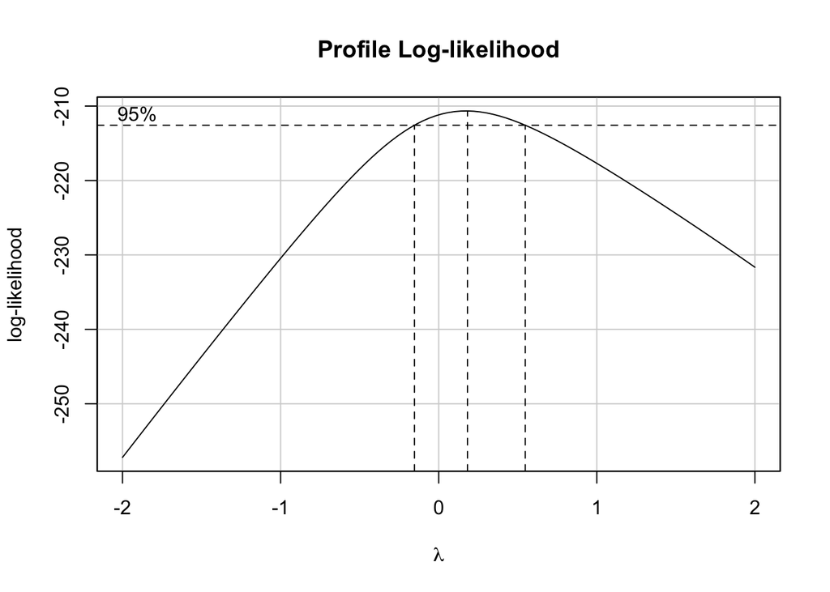

```r
carprice.lm <- lm(Price ~ Mileage, data=carprice)
boxCox(carprice.lm)
```

This graph helps me to decide what is my λ, 0 seems like to be my best fit, so I will choose my λ to be 0. Also in this way, I will know that I have to use the log function as the way to transform my data. That’s the best since log carry the interpretation with it.

```r
carprice.lm.t <- lm(log(Price) ~ Mileage, data=carprice)
summary(carprice.lm.t) |>
  pander()
```

|  | Estimate | Std. Error | t value | Pr(>\|t\|) |
| --- | --- | --- | --- | --- |
| **(Intercept)** | 10.92 | 0.09799 | 111.4 | 3.2e-28 |
| **Mileage** | -1.401e-05 | 1.069e-06 | -13.11 | 5.731e-11 |

Fitting linear model: log(Price) ~ Mileage

| Observations | Residual Std. Error | $R^2$ | Adjusted $R^2$ |
| --- | --- | --- | --- |
| 21 | 0.2699 | 0.9005 | 0.8952 |

This is the regression line after I transform my data. And from the table, I will know 10.92 is my intercept, and -0.00001401 is my slope.

$$\underset{\text{Log Car Price}}{\log(Y'_i)} = 10.92 - 0.00001401 \underset{\text{Mileage}}{X_i}$$

After the transformation, this equation can help me to find the best price that I should sell my car.

$$\underset{\text{Car Price}}{\hat{Y}_i} = e^{10.92 - 0.00001401 \underset{\text{Mileage}}{X_i}}$$

```r
mypred<- predict(carprice.lm.t, data.frame(Mileage=161250), interval="prediction")
pander(exp(mypred))
```

| fit | lwr | upr |
| --- | --- | --- |
| 5776 | 3136 | 10637 |

After I put 161250 mils as my mileage, I got $5775.5 as the best price that I can sell my car. Since I sold my car at $6500, I did a good job!

Back to top